# Analysis of COVID & Census Response Rates

LD

5/12/2020

#### Data as of May 4, 2020.

Data update pending. Overall, with COVID-19 cases and Census self-response rates, we have seen stable trends over the past month.

#### Median/mean of HTC scores and COVID cases per 100k per neighborhood

Median & Mean of mean neigbhorhood HTC scores:

- Half of neighborhoods have a mean HTC score below 43.8, half of neighborhoods have a mean HTC score above 43.8.

Median & Mean of confirmed COVID-19 cases per 100k residents:

- Half of neighborhoods have more than 202.93 COVID-19 cases per 100k residents.

## Create typology

- If the neighborhood mean HTC score is above the median –> High HTC
- If the neighborhood mean HTC score is at or below the median –> Low HTC
- If the neighborhood COVD-19 cases per 100k is above the median –> High COVID
- If the neighborhood COVD-19 cases per 100k is at or below the median –> Low COVID

## Plot Response Rate by Typology

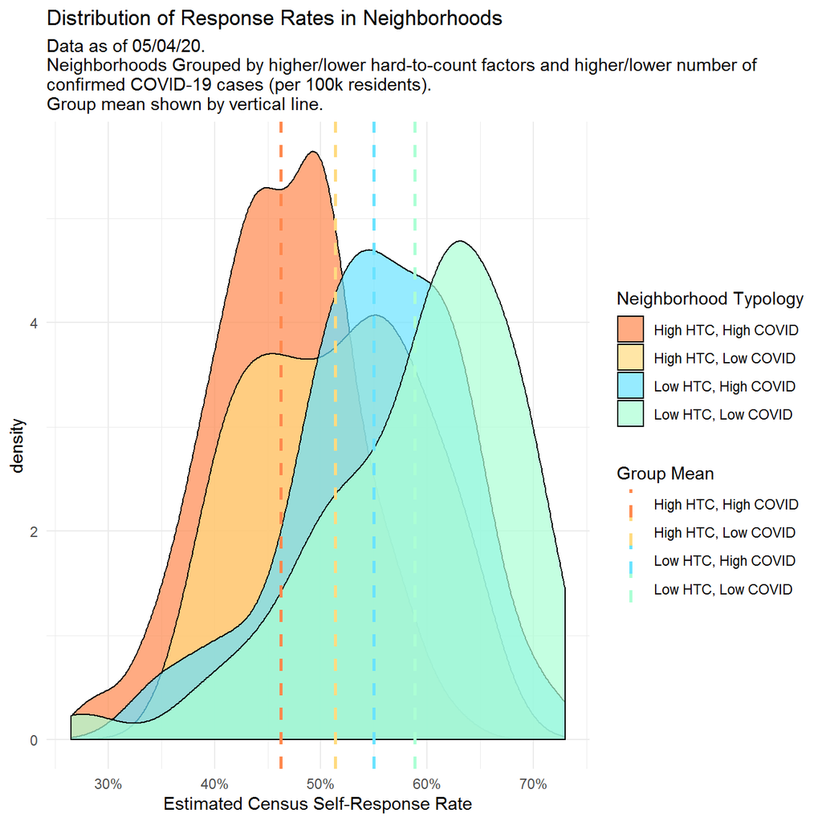

## Analysis

- The group of neighborhoods with higher HTC scores and higher rates of COVID-19 cases (High HTC, High COVID) has overall lower response rates, and a response rate distribution that trends to lower response rates.
  - The ‘peak’ of response rates is ~5 percentage points lower in High HTC/High COVID neighborhoods than in High HTC/Low COVID neighborhoods.
- The group of neighborhood with lower HTC scores and higher rates of COVID-19 cases (Low HTC, High COVID) has overall lower response rates, and a response rate distrubtion that trends lower than the response rate distribution for Low HTC, Low COVID neighborhoods.
  - The ‘peak’ of response rates in Low HTC, High COVID neighborhoods is ~7 percentage points lower than that of Low HTC, Low COVID neighborhoods.
- We cannot separate the effects of COVID-19 from the effects of hard-to-count characteristics on Census self-response. However, we see a lower self-response rate among neighborhoods that are harder to count and have higher rates of COVID-19 cases than we do among HTC neighborhoods with lower rates of COVID cases.
  - Similarly, in neighborhoods that are **not** considered hard-to-count, we see lower response rates in areas with higher rates of COVID than we do in neighborhoods with lower rates of COVID.
- The mean response rate in neighborhoods with lower rates of COVID is higher than the mean response rates in neighborhoods with higher rates of COVID, even when accounting for HTC characteristics.

## Notes on Impact of Hard-to-Count Characteristics and COVID on Census Self-Response

- The [Hard-to-Count (HTC)](https://census.ca.gov/california-htc/) tract designation is a specific metric developed by California Complete Count.
- HTC factors include: lack of internet access (not able to respond to the Census at home, less likely to know about the Census), poverty (people working multiple jobs to make ends meet may have less time to engage in the Census or activities where the Census is advertised), limited English proficiency, and factor related to mistrust in government such as overcrowded households and foreign born populations.
- Hard-to-count (HTC) tracts have become even harder to count since the outbreak of COVID-19 and stay-at-home orders.
- Communities of color have been hit harder by the effects of COVID-19 (reference APCA COVID Race/Class work).
- CBOs had planned to conduct culturally and linguistically appropriate *in-person* census outreach in HTC communities, especially those that lack access to internet. Due to COVID-19, these outreach plans have been put on pause.
- The impact of COVID-19 on census response rates is inextricable from HTC characteristics of a community. At the root of what makes a community harder to count are systemic inequities and racism. These systemic inequities distribute the effects of a global pandemic unequally as well.
- Looking at the plot–we cannot separate the effects of COVID-19 from the effects of hard-to-count characteristics on Census self-response. However, we see a lower self-response rate among neighborhoods that are harder to count and have higher rates of COVID-19 cases than we do among HTC neighborhoods with lower rates of COVID cases.